# Mini-Project 2

Beth Campbell, Lola Roberts and Felicia Villalobos

March 22, 2018

The amount of money a candidate’s campaign receives may widely influence whether they win or lose an election. Campaign fundraising has become a significant part of the democratic process, candidates running for high office must spend the majority of their time raising money for re-election. Candidates receive such a high volume of contributions that the Federal Election Commission has had to limit the amount of money people/organizations can contribute in order to strive for a more level playing field. How much money do candidates actually receive and will large amounts of money swing the outcome of an election? Also, how far will the other party go in terms of spending money against an opposing candidate?

```r
library(tidyverse)
library(ggplot2)
library(gridExtra)
```

```r
load("house_elections.rda")
load("candidates.rda")
load("committees.rda")
load("contributions.rda")
```

```r
# what we want from candidates
# candFilter <- candidates %>%
#   select(cand_id, cand_name, cand_party_affiliation, cand_state)

# what we want from candidates
candidateSelection <- candidates %>%
  select(cand_id, cand_name, cand_party_affiliation, cand_state)

# what we want from house_elections
houseElection <- house_elections %>%
  select(fec_id, state, candidate_name, general_votes, ge_winner)

# what we want from contributions
contrFilter <- contributions %>%
  select(cmte_id, name, state, transaction_amt, cand_id)

# what we want from committees
committeeFilter <- committees %>%
  select(cmte_id, cmte_name, cmte_party_affiliation, cmte_type, org_type)

#joining the data set of committe to contributions
committeContribution <- contrFilter %>%
  full_join(committeeFilter, contrFilter, by = "cmte_id")

# joining the data set of candidate and house election
houseCandid <- houseElection %>%
  full_join(candidateSelection, houseElection, by = c("fec_id" = "cand_id"))

# joing the previous joined data set with contributions and editing the data set to show what we want
houseCandContrib <- houseCandid %>%
  inner_join(committeContribution, houseCandid, by = c("fec_id" = "cand_id")) %>%
  filter(!is.na(cand_name),
         !is.na(cmte_id),
         !is.na(name),
         !is.na(transaction_amt),
         !is.na(general_votes),
         transaction_amt > 0) %>%
  mutate(ge_winner = ifelse(ge_winner == "W", 1, 0),
         contrParty = ifelse(cmte_party_affiliation == "REP", 1,
                            ifelse(cmte_party_affiliation == "DEM", 1, 1)),
         candParty = ifelse(cand_party_affiliation == "REP", 1,
                            ifelse(cand_party_affiliation == "DEM", 1000, 0))) %>%
  group_by(cand_name, cand_state) %>%
  summarize(totalContributionCandidate = sum(transaction_amt),
            general_votes = sum(general_votes),
            ge_winner = sum(ge_winner),
            contributionParty = sum(contrParty),
            candidateParty = sum(candParty)) %>%
  mutate(ge_winner = ifelse(ge_winner > 1, "Win", "Lose"),
         candidateParty = ifelse(candidateParty > 2000, "Dem", "Rep")) %>%
  arrange(desc(totalContributionCandidate)) %>%
  head(10)
```

```r
# writing a function for the graphs, so we don't have the same code repeated
graph <- function(dataSet, xElement, yElement, fillElement, yAxisLab, legendTitle) {
  ggplot(dataSet, aes(x = xElement, y = yElement, fill = fillElement)) +
    geom_bar(stat = "identity") +
    theme(axis.text.x = element_text(size = rel(0.7), angle = 70, hjust = 1)) +
    xlab("Candidates") +
    ylab(yAxisLab) +
    guides(fill = guide_legend(title = legendTitle))
}
```

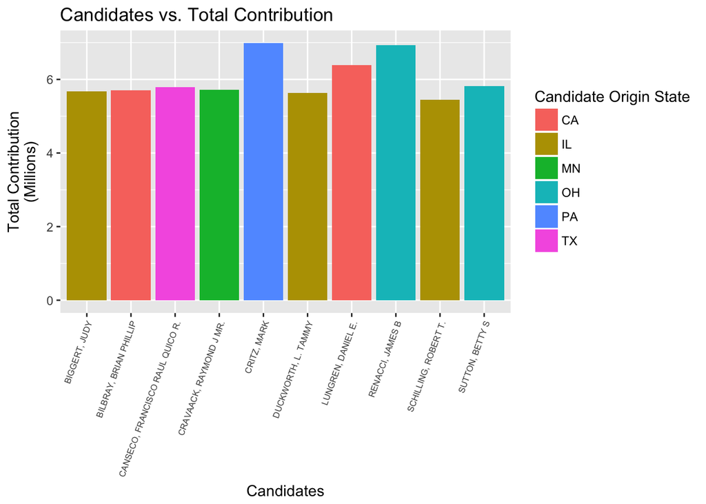

```r
#graphic showing candidate vs. total contribution
candVs.Money <- graph(houseCandContrib, houseCandContrib$cand_name, houseCandContrib$totalContributionCandidate,
                      houseCandContrib$cand_state, "Total Contribution\n(Millions)", "Candidate Origin State") +
  scale_y_continuous(breaks = c(0e+00, 2e+06, 4e+06, 6e+06),
                     labels = c(0, 2, 4, 6)) +
  ggtitle("Candidates vs. Total Contribution")

candVs.Money
```

Next let’s see if there’s a correlation between the amount of money spent on the candidate and the votes they receive during the election. Only two of the top ten fundraiser candidates won their elections. This data graphic brings in an important point of information about money raised during campaigns. The Federal Election Commission only records the money spent on a candidate, not whether that money is used for or against that candidate. (Ex: In an advertisement denouncing the candidate) Since eight of the ten candidates lost their election, it could be assumed that a significant portion of that money was used against them, or that the candidate was a lost cause, no amount of money would guarantee their win. To be sure, more context about this election cycle and candidate popularity would be required.

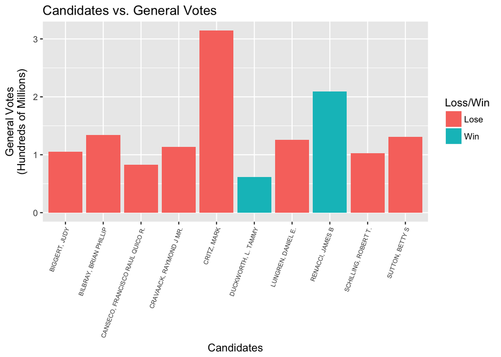

```r
candVs.Vote <- graph(houseCandContrib, houseCandContrib$cand_name, houseCandContrib$general_votes, houseCandContrib$ge_winner, "General Votes\n(Hundreds of Millions)", "Loss/Win") +
  scale_y_continuous(breaks = c(0e+00, 1e+08, 2e+08, 3e+08),
                     labels = c(0, 1, 2, 3)) +
  ggtitle("Candidates vs. General Votes")

candVs.Vote
```

Where these contributions are coming from is important when determining if the money was used against or for a candidate. In the next data graphic, the number of contributions each of the ten candidates received are separated out by which organization they came from, their own party, the opposing party, or other (another party or an independent organization). The majority of contributions candidates received are from a committee not affiliated with a major party which makes it hard to learn their motive. Also, all the Republican candidates received around the same number of contributions from a committee affiliated with the Republican party.

```r
# candVs.Contribution <- graph(houseCandContrib$contributionParty, houseCandContrib$candidateParty, "Total Number of Contributions")
#
# candVs.Contribution

Democratic = c(15, 30, 22, 10, 96, 65, 15, 15, 30, 91)

Republican = c(62, 76, 80, 66, 25, 6, 77, 73, 67, 10)

Other = c(923, 821, 842, 631, 1801, 426, 861, 1043, 664, 666)

candidateName = c("Biggert, Judy", "Bilbray, Brian", "Canseco, Francisco", "Cravaack, Raymond", "Critz, Mark", "Duckworth, Tammy", " Lungren, Daniel ", "Renacci, James ", "Schilling, Robert ", "Shutton, Betty S")

candidateParty = c("R", "R", "R", "R", "D", "D", "R", "R", "R", "D" )

candParty <- houseCandContrib %>%
  select(candidateParty)

party = data_frame(Democratic, Republican, Other, candidateName, candidateParty)

canDemParty <- party %>%
  gather(party, numberOfContributions, -candidateName, -candidateParty) %>%
  filter(candidateParty == "D")

# creating the bar graph for candidates vs. the party they recieved money from

candDemVs.Contribution <- graph(canDemParty, canDemParty$candidateName, canDemParty$numberOfContributions, canDemParty$party, "Number of Contributions", "Candidate Party Affiliation") +
  ggtitle("Democatic Candidate vs.\n Number of Contributions By Party") +
  scale_fill_manual(values=c(Democratic="blue", Republican="red", Other = "grey")) +
  theme(legend.position="none") +
  theme(plot.title = element_text(size = 70, face = "bold")) +
  theme(axis.text.x = element_text(size = rel(5))) +
  theme(axis.text.y = element_text(size = rel(5))) +
  theme(axis.ticks.length = unit(1.5, "lines")) +
  theme(axis.title.x = element_text(size = 50, face = "bold"))+
  theme(axis.title.y = element_text(size = 50, face = "bold"))

# candDemVs.Contribution


canRepParty <- party %>%
  gather(party, numberOfContributions, -candidateName, -candidateParty) %>%
  filter(candidateParty == "R")

candRepVs.Contribution <- graph(canRepParty, canRepParty$candidateName, canRepParty$numberOfContributions, canRepParty$party, "", "Candidate Party\n Affiliation") +
  ggtitle("Republican Candidate vs.\n Number of Contributions By Party") +
  scale_fill_manual(values=c(Democratic="blue", Republican="red", Other = "grey")) +
  scale_y_continuous(breaks = c(0, 500, 1000, 1500, 2000)) + ylim(0, 2000) +
  theme(legend.position = c(0, .7)) +
  theme(plot.title = element_text(size = 70, face = "bold")) +
  theme(axis.text.x = element_text(size = rel(5))) +
  theme(axis.text.y = element_text(size = rel(0))) +
  theme(axis.ticks.y = element_blank()) +
  theme(axis.ticks.length = unit(1.5, "lines")) +
  theme(axis.title.x = element_text(size = 50, face = "bold")) +
  theme(legend.title = element_text(size = rel(5))) +
  theme(legend.text = element_text(size = rel(5))) +
  guides(fill = guide_legend(keywidth = 3,
                             keyheight = 5,
                             title = "Contribution Affiliation"))

# candRepVs.Contribution

grid.arrange(
  arrangeGrob(
  candDemVs.Contribution,
  candRepVs.Contribution,
  nrow = 1,
  ncol = 2
))
```

[figure not shown]

Breaking down the influences of a political election is complicated. Many factors contribute to which candidate wins an election, and the amount of money spent on each candidate or their campaign only being one of them. These data graphics attempt break down how money can alter the outcome an election. Although a lot of money can be raised for a candidate, in end, it might not matter. For example, 7 million dollars was spent on Mark Critz, but it all went to waste in the end since he did not win.

[^1]

[^1]: https://github.com/lolabfr/sds192-mp2.git